# Joining data

# Overview

These exercises will help you practice applying functions in the `join` family and the `stringr` and `glue` packages. You will use two datasets that describe a TV show called ‘The Office’.

## Pre-requisites

Before starting these exercises, you should have a good understanding of

1. The [Joining data](https://rstudio.cloud/learn/primers/4.3) Primer.
2. Chapter 13 of [R for Data Science](https://r4ds.had.co.nz/relational-data.html)

## Setup

Packages used for this exercise set are loaded below.

```r
knitr::opts_chunk$set(echo = TRUE, message = FALSE)

library(gghighlight)
library(tblStrings)
library(tidyverse)
library(glue)
library(gt)
```

## Data dictionary

The analysis will involve two datasets:

- `office_ratings.csv`: the IMDB rating for each episode.
- `office_director_and_writers.csv` the writers and director of each episode.

```r
ratings_descr <-
  c("season"      = "Season that the episode aired",
    "episode"     = "Episode number, relative to Season start",
    "title"       = "Title of the episode",
    "imdb_rating" = "Mean IMDB rating",
    "total_votes" = "Total number of IMDB members who rated the episode",
    "air_date"    = "Date that the episode aired")

drctr_wrtr_descr <-
  c("season"   = "Season that the episode aired",
    "title"    = "Title of the episode",
    "director" = "Name of the episode's director",
    "writer"   = "Name of contributing writer")

data_names <- c("ratings", "director and writers")

tbls <- list(ratings_descr, drctr_wrtr_descr) %>%
  map2(.y = data_names,
    ~ enframe(.x) %>%
      gt(rowname_col = "name") %>%
      tab_stubhead(label = 'Variable name') %>%
      cols_label(value = 'Variable description') %>%
      cols_align('left') %>%
      tab_header(title = glue('Description of {.y} data'))
  )

tbls[[1]]
```

Description of ratings data

| Variable name | Variable description |
| --- | --- |
| season | Season that the episode aired |
| episode | Episode number, relative to Season start |
| title | Title of the episode |
| imdb_rating | Mean IMDB rating |
| total_votes | Total number of IMDB members who rated the episode |
| air_date | Date that the episode aired |

```r
tbls[[2]]
```

Description of director and writers data

| Variable name | Variable description |
| --- | --- |
| season | Season that the episode aired |
| title | Title of the episode |
| director | Name of the episode's director |
| writer | Name of contributing writer |

## Import

You can import the two datasets using the `read_csv()` function. Note that your project directory is the root of the file path.

```r
# Read in both the 'office_ratings.csv' file and
# the 'office_director_and_writers.csv' file.
```

# Problem 1

Conduct exploratory data analysis of the `office_ratings` data and produce the figure shown below.

Note: I used the `gghighlight` package to add selective labels.

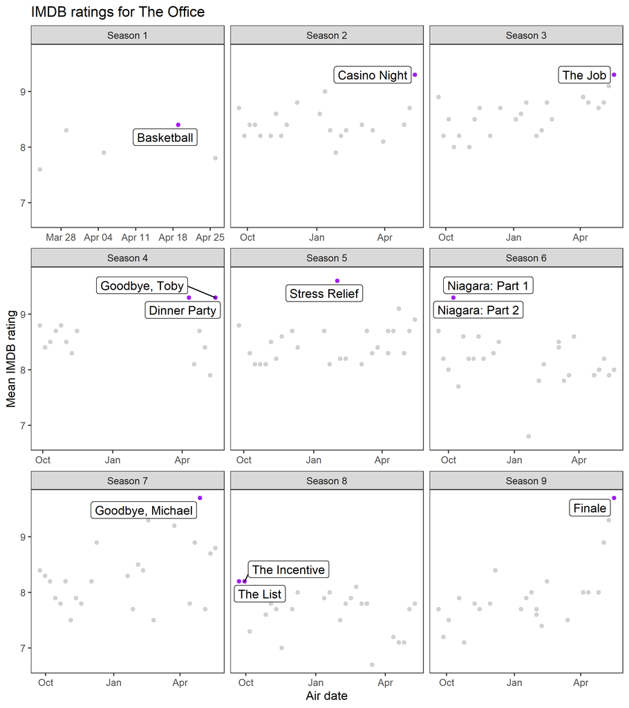

```r
knitr::include_graphics('solutions/01_solution.png')
```

# Problem 2

Identify the episode names that are present in `office_ratings` but not in `office_director_and_writers`. Then, identify the episode names that are present in `office_director_and_writers` but not in `office_ratings`. I saved each vector of character values in the list printed below.

```r
readr::read_rds('solutions/02_solution.rds')
```

```
## $titles_unmatched_directors
##  [1] "E-Mail Surveilance"                  "Boys & Girls"
##  [3] "A Benihana Christmas (Parts 1&2)"    "The Job (Parts 1&2)"
##  [5] "The Job (Parts 1&2)"                 "Fun Run (Parts 1&2)"
##  [7] "Dunder Mifflin Infinity (Parts 1&2)" "Launch Party (Parts 1&2)"
##  [9] "Money (Parts 1&2)"                   "Goodbye, Toby (Parts 1&2)"
## [11] "Goodbye, Toby (Parts 1&2)"           "Weight Loss (Parts 1&2)"
## [13] "Weight Loss (Parts 1&2)"             "Stress Relief (Parts 1&2)"
## [15] "Lecture Circuit (Part 1)"            "Lecture Circuit (Part 2)"
## [17] "The Michael Scott Paper Company"     "Niagara (Parts 1&2)"
## [19] "Niagara (Parts 1&2)"                 "The Manager and the Salesman"
## [21] "The Delivery (Parts 1&2)"            "The Delivery (Parts 1&2)"
## [23] "The Cover"                           "The Cover"
## [25] "s*x Ed"                              "Classy Christmas (Parts 1&2)"
## [27] "Search Committee (Parts 1&2)"        "Test The Store"
```

[output cut: 18 more lines]

# Problem 3

Design and implement a strategy to harmonize the episode names between these two data sets so that they can be joined. When you are finished, `anti_join()`ing the two data sets should produce an empty data set.

Once the names are harmonized, left join the `office_director_and_writers` data with the `office_ratings` data

Hints:

- I used the following functions to harmonize episode names: `tolower()`, `str_remove_all()`, and `str_replace()`.
- Don’t worry if it takes more than a few steps to get everything harmonized. Just take it one step at a time.

```r
readr::read_rds('solutions/03_solution.rds')
```

| season | title | director | writer | episode | imdb_rating | total_votes | air_date |
| --- | --- | --- | --- | --- | --- | --- | --- |
| 1 | pilot | Ken Kwapis | Ricky Gervais | 1 | 7.6 | 3706 | 2005-03-24 |
| 1 | pilot | Ken Kwapis | Stephen Merchant | 1 | 7.6 | 3706 | 2005-03-24 |
| 1 | pilot | Ken Kwapis | Greg Daniels | 1 | 7.6 | 3706 | 2005-03-24 |
| 1 | diversity day | Ken Kwapis | B.J. Novak | 2 | 8.3 | 3566 | 2005-03-29 |
| 1 | health care | Ken Whittingham | Paul Lieberstein | 3 | 7.9 | 2983 | 2005-04-05 |
| 1 | the alliance | Bryan Gordon | Michael Schur | 4 | 8.1 | 2886 | 2005-04-12 |
| 1 | basketball | Greg Daniels | Greg Daniels | 5 | 8.4 | 3179 | 2005-04-19 |
| 1 | hot girl | Amy Heckerling | Mindy Kaling | 6 | 7.8 | 2852 | 2005-04-26 |
| 2 | the dundies | Greg Daniels | Mindy Kaling | 1 | 8.7 | 3213 | 2005-09-20 |
| 2 | sexual harassment | Ken Kwapis | B.J. Novak | 2 | 8.2 | 2736 | 2005-09-27 |

[output cut: 219 more lines]

# Problem 4

Summarize the merged data by computing

1. the number of episodes that each writer contributed to.
2. the mean rating of episodes by writer.

Using the summarized data, create a new column that indicates who is a `top_writer`. The criteria for being identified as a `top_writer` are having a mean episode rating > 8.6 or writing > 20 episodes.

Using the summarized and mutated data, reproduce the plot below.

Notes:

- I used `gghighlight` to selectively label `top_writer` values.

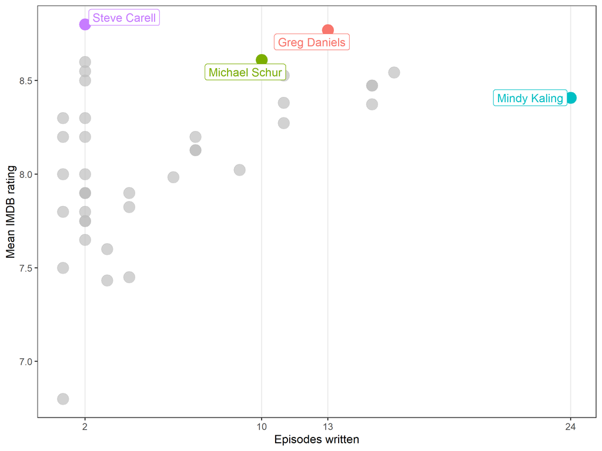

```r
knitr::include_graphics('solutions/04_solution.png')
```

# Problem 5

Merge the data you created in problem 4 with the data you previously merged in problem 3, and then create a table that shows the top 5 episodes for each `top_writer`, arranged by rating. If the `top_writer` wrote k < 5 episodes, just show the k episodes that the writer contributed to.

Notes:

- `group_by()`, `arrange()`, and `slice()` work extremely well together.

```r
readr::read_rds('solutions/05_solution.rds')
```

|  | Air date | IMDB rating |
| --- | --- | --- |
| Top 5 episodes out of 10 written by Michael Schur |  |  |
| Christmas Party | December 6, 2005 | 8.8 |
| Traveling Salesmen | January 11, 2007 | 8.6 |
| The Return | January 18, 2007 | 8.8 |
| The Negotiation | April 5, 2007 | 8.9 |
| The Job | May 17, 2007 | 9.3 |
| Top 5 episodes out of 24 written by Mindy Kaling |  |  |
| The Injury | January 12, 2006 | 9.0 |
| Niagara | October 8, 2009 | 9.3 |
| Niagara | October 8, 2009 | 9.3 |
| Classy Christmas | December 9, 2010 | 8.9 |
| Michael's Last Dundies | April 21, 2011 | 8.9 |
| Top 2 episodes out of 2 written by Steve Carell |  |  |
| Casino Night | May 11, 2006 | 9.3 |
| Survivor Man | November 8, 2007 | 8.3 |
| Top 5 episodes out of 13 written by Greg Daniels |  |  |
| Beach Games | May 10, 2007 | 9.1 |
| Niagara | October 8, 2009 | 9.3 |
| Niagara | October 8, 2009 | 9.3 |
| Goodbye, Michael | April 28, 2011 | 9.7 |
| Finale | May 16, 2013 | 9.7 |